# Coding Challenge — Data Scientist

Moritz Buck

# Load packages

Most packages where installed with conda, only the `arff`-parser needs to be installed manually

```r
library(ggplot2)
library(data.table)
library(maps)
library(tidyr)
library(dplyr)
library(ggpubr)
library(farff)
library(pheatmap)
library(MASS)

if (!require("farff", quietly = TRUE))
    install.packages("farff", repos = "https://mirror.accum.se/mirror/CRAN/")
```

# Load data

```r
data = as.data.table(readARFF("/home/moritz/projects/X003_coburg/data/freMTPL2freq.arff"))
var = as.data.table(readARFF("/home/moritz/projects/X003_coburg/data/freMTPL2sev.arff"))
census_data = as.data.table(read.csv('/home/moritz/projects/X003_coburg/data/census_data.csv', header = TRUE, sep = ','))
```

# joining and summarizing

```r
svar = var[, .(total_claim_amount = sum(ClaimAmount), avg_claim_amount = mean(ClaimAmount), nb_claims = length(ClaimAmount)),  by = IDpol]

fulldata = data %>% left_join(svar, by = c('IDpol' = 'IDpol'))
fulldata[is.na(total_claim_amount) , total_claim_amount := 0]
fulldata[is.na(avg_claim_amount) , avg_claim_amount := 0]
fulldata[is.na(nb_claims) , nb_claims := 0]
```

# checking for autocorrelation

```r
cont_columns = c("ClaimNb", "Exposure", "VehPower", "VehAge", "DrivAge", "BonusMalus", "Density", "total_claim_amount", "avg_claim_amount", "nb_claims")
cat_cols = setdiff(colnames(fulldata) , cont_columns) [2:5]

pheatmap(cor(fulldata[,..cont_columns]), title = "continuous data correlations")
```

[output not shown]

ClaimNbs and nb_claims are obviously correlated, but weirdly not the same, I guess the difference is the claims reported and claims processed, I will use only nb_claims (the number of claims computed from `freMTPL2sev.arff` for each insurance ID).

Also, obviously, total_claim amount correlates with avg_claim_amount as most insurances only have one claim. Similarily nb_claims and claim amounts correlate. As well as correlates with nb_claim (and claim amounts).

BonusMalus relates driver age, and exposure, as BonusMalus in France mainly depends on how long one was insured. I would remove it from modelling as it is probably a composite factor of the others.

# Exploring the data a bit

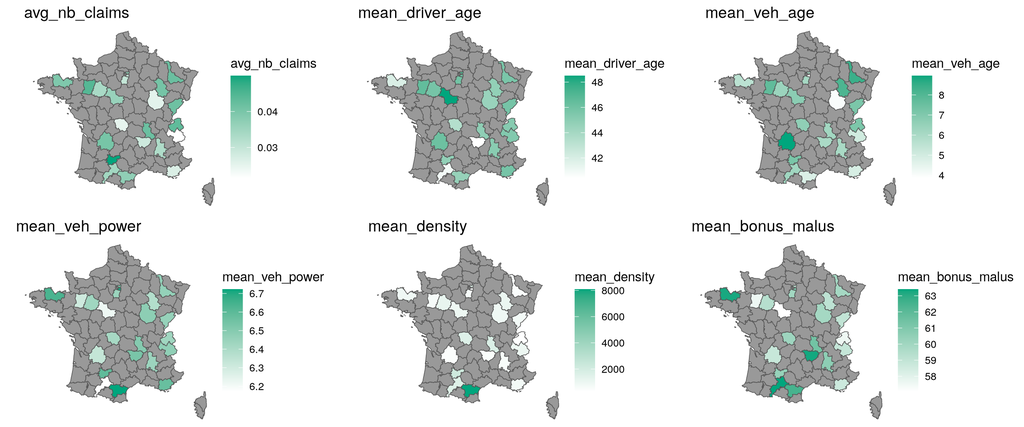

No very obivous geographic relationaship

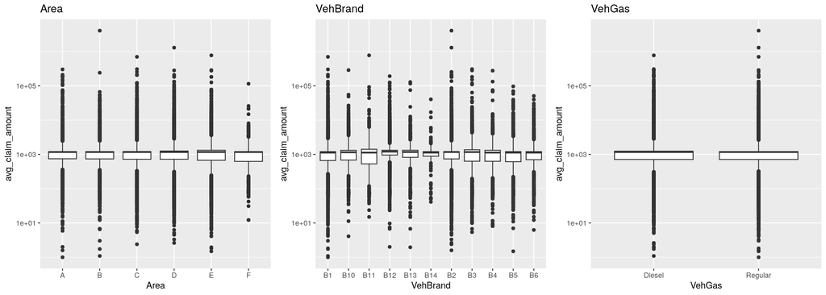

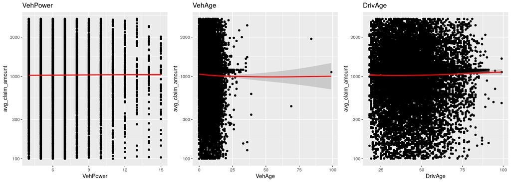

Some small shifts in claim amount with VehAge and DrivAge

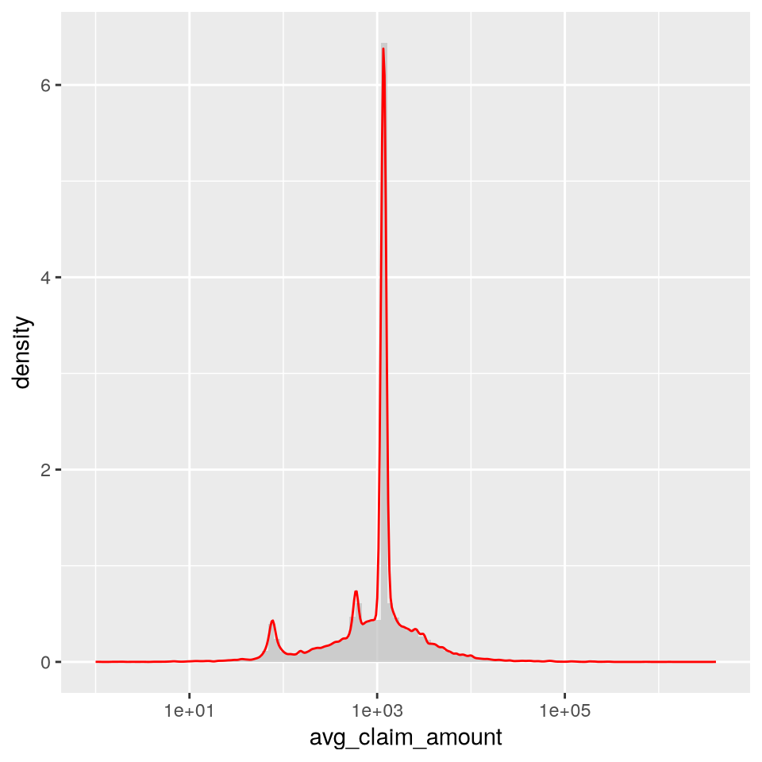

Claim amounts seam very consistent.

```r
table(fulldata$nb_claims)
```

```
##
##      0      1      2      3      4      5      6      8      9     11     16
## 653069  23571   1298     62      5      2      1      1      1      2      1
```

Most insurances have made no claims and very few more than 3.

## Modelling

We will split the modelling into two parts, the risk, as in the probability of getting into an accident during a year, and a second model estimating the value of the damage.

### Risk estimate

Subsetting the data to insurances that were running at least 90% of a year:

```r
sub_data = fulldata[Exposure > 0.9]
nrow(sub_data)/nrow(fulldata)
```

```
## [1] 0.2830255
```

[1] is the ratio of kept data for learning the model

Running a full model with a negative binomial regression

```r
modelling_frequency = glm.nb(nb_claims ~ Area+VehPower+VehGas+VehAge+DrivAge+VehBrand+Density+Region,data=sub_data)
summary(modelling_frequency)
```

```
##
## Call:
## glm.nb(formula = nb_claims ~ Area + VehPower + VehGas + VehAge +
##     DrivAge + VehBrand + Density + Region, data = sub_data, init.theta = 1.513197623,
##     link = log)
##
## Coefficients:
##                 Estimate Std. Error z value Pr(>|z|)
## (Intercept)   -2.723e+00  7.713e-02 -35.306  < 2e-16 ***
## AreaB          8.497e-02  3.951e-02   2.151 0.031500 *
## AreaC          1.785e-01  3.287e-02   5.430 5.64e-08 ***
## AreaD          3.363e-01  3.616e-02   9.299  < 2e-16 ***
## AreaE          4.655e-01  5.062e-02   9.195  < 2e-16 ***
## AreaF          3.223e-01  1.940e-01   1.661 0.096676 .
## VehPower       2.298e-02  5.654e-03   4.065 4.81e-05 ***
## VehGasRegular -2.005e-01  2.044e-02  -9.807  < 2e-16 ***
## VehAge        -3.226e-02  2.032e-03 -15.871  < 2e-16 ***
## DrivAge       -2.898e-03  7.021e-04  -4.127 3.67e-05 ***
## VehBrandB10    7.614e-02  6.045e-02   1.260 0.207799
## VehBrandB11    1.494e-01  6.735e-02   2.219 0.026514 *
## VehBrandB12   -9.465e-02  4.623e-02  -2.047 0.040627 *
## VehBrandB13    1.482e-01  6.616e-02   2.240 0.025101 *
## VehBrandB14   -2.433e-01  1.384e-01  -1.758 0.078771 .
## VehBrandB2     1.218e-02  2.557e-02   0.476 0.633860
## VehBrandB3     6.641e-02  3.735e-02   1.778 0.075388 .
## VehBrandB4     8.701e-02  4.906e-02   1.773 0.076159 .
## VehBrandB5     1.127e-01  4.147e-02   2.717 0.006584 **
## VehBrandB6    -1.200e-02  4.847e-02  -0.248 0.804517
## Density        8.593e-06  7.787e-06   1.104 0.269795
## RegionR21      5.243e-02  2.683e-01   0.195 0.845061
## RegionR22      1.366e-01  1.155e-01   1.182 0.237108
## RegionR23     -2.074e-01  1.378e-01  -1.505 0.132348
## RegionR24     -1.403e-01  5.288e-02  -2.653 0.007975 **
## RegionR25     -1.342e-02  8.115e-02  -0.165 0.868658
## RegionR26      5.163e-02  1.018e-01   0.507 0.612166
## RegionR31     -4.623e-02  7.651e-02  -0.604 0.545708
## RegionR41     -3.130e-01  8.305e-02  -3.769 0.000164 ***
## RegionR42     -1.479e-01  1.723e-01  -0.859 0.390611
## RegionR43     -3.490e-01  3.623e-01  -0.963 0.335326
## RegionR52     -4.769e-02  6.070e-02  -0.786 0.432109
```

[output cut: 11 more lines]

```
## Signif. codes:  0 '***' 0.001 '**' 0.01 '*' 0.05 '.' 0.1 ' ' 1
##
## (Dispersion parameter for Negative Binomial(1.5132) family taken to be 1)
##
##     Null deviance: 57550  on 191894  degrees of freedom
## Residual deviance: 56457  on 191853  degrees of freedom
## AIC: 83161
##
## Number of Fisher Scoring iterations: 1
##
##
##               Theta:  1.513
##           Std. Err.:  0.167
##
##  2 x log-likelihood:  -83074.524
```

```r
anova(modelling_frequency)
```

```
## Analysis of Deviance Table
##
## Model: Negative Binomial(1.5132), link: log
##
## Response: nb_claims
##
## Terms added sequentially (first to last)
##
##
##          Df Deviance Resid. Df Resid. Dev  Pr(>Chi)
## NULL                    191894      57550
## Area      5   444.55    191889      57105 < 2.2e-16 ***
## VehPower  1    29.06    191888      57076 7.000e-08 ***
## VehGas    1   172.55    191887      56904 < 2.2e-16 ***
## VehAge    1   270.53    191886      56633 < 2.2e-16 ***
## DrivAge   1    23.56    191885      56610 1.210e-06 ***
## VehBrand 10    29.80    191875      56580  0.000924 ***
## Density   1     4.55    191874      56575  0.032956 *
## Region   21   118.47    191853      56457 1.364e-15 ***
## ---
## Signif. codes:  0 '***' 0.001 '**' 0.01 '*' 0.05 '.' 0.1 ' ' 1
```

We will keep the full model for now.

Modelling the value of the damage with a Gamma dsitribution, keeping only factors relevant for the vehicle.

```r
modelling_damageprice = glm(avg_claim_amount ~ BonusMalus+VehPower+VehGas+VehAge+VehBrand,family=Gamma(link = "log"),data=fulldata[nb_claims >0])
anova(modelling_damageprice)
```

```
## Analysis of Deviance Table
##
## Model: Gamma, link: log
##
## Response: avg_claim_amount
##
## Terms added sequentially (first to last)
##
##
##            Df Deviance Resid. Df Resid. Dev       F    Pr(>F)
## NULL                       24943      42435
## BonusMalus  1  1325.79     24942      41109 21.1068 4.365e-06 ***
## VehPower    1   179.52     24941      40930  2.8580   0.09093 .
## VehGas      1    35.33     24940      40894  0.5625   0.45326
## VehAge      1    48.66     24939      40846  0.7747   0.37877
## VehBrand   10   522.76     24929      40323  0.8322   0.59739
## ---
## Signif. codes:  0 '***' 0.001 '**' 0.01 '*' 0.05 '.' 0.1 ' ' 1
```

Some factors seam irrelevant, alternate models are tried:

```r
nogas <- update(modelling_damageprice, . ~ . - VehGas)
anova(modelling_damageprice, nogas)
```

```
## Analysis of Deviance Table
##
## Model 1: avg_claim_amount ~ BonusMalus + VehPower + VehGas + VehAge +
##     VehBrand
## Model 2: avg_claim_amount ~ BonusMalus + VehPower + VehAge + VehBrand
##   Resid. Df Resid. Dev Df Deviance      F Pr(>F)
## 1     24929      40323
## 2     24930      40361 -1  -38.134 0.6071 0.4359
```

```r
noage <- update(modelling_damageprice, . ~ . - VehAge)
anova(modelling_damageprice, noage)
```

```
## Analysis of Deviance Table
##
## Model 1: avg_claim_amount ~ BonusMalus + VehPower + VehGas + VehAge +
##     VehBrand
## Model 2: avg_claim_amount ~ BonusMalus + VehPower + VehGas + VehBrand
##   Resid. Df Resid. Dev Df Deviance      F Pr(>F)
## 1     24929      40323
## 2     24930      40334 -1  -11.457 0.1824 0.6693
```

```r
nopow <- update(modelling_damageprice, . ~ . - VehPower)
anova(modelling_damageprice, nopow)
```

```
## Analysis of Deviance Table
##
## Model 1: avg_claim_amount ~ BonusMalus + VehPower + VehGas + VehAge +
##     VehBrand
## Model 2: avg_claim_amount ~ BonusMalus + VehGas + VehAge + VehBrand
##   Resid. Df Resid. Dev Df Deviance      F Pr(>F)
## 1     24929      40323
## 2     24930      40428 -1  -105.41 1.6782 0.1952
```

```r
onlypow <- update(modelling_damageprice, . ~ . - VehAge - VehGas)
onlybrand <- update(modelling_damageprice, . ~ . - VehPower - VehAge - VehGas)
anova(onlypow, onlybrand)
```

```
## Analysis of Deviance Table
##
## Model 1: avg_claim_amount ~ BonusMalus + VehPower + VehBrand
## Model 2: avg_claim_amount ~ BonusMalus + VehBrand
##   Resid. Df Resid. Dev Df Deviance      F Pr(>F)
## 1     24931      40382
## 2     24932      40497 -1  -115.52 1.7537 0.1854
```

We will only keep BonusMalus (power is a bit borderline….).

```r
modelling_damageprice = glm(avg_claim_amount ~ BonusMalus,family=Gamma(link = "log"),data=fulldata[nb_claims >0])
summary(modelling_damageprice)
```

```
##
## Call:
## glm(formula = avg_claim_amount ~ BonusMalus, family = Gamma(link = "log"),
##     data = fulldata[nb_claims > 0])
##
## Coefficients:
##             Estimate Std. Error t value Pr(>|t|)
## (Intercept) 6.944953   0.208000  33.389  < 2e-16 ***
## BonusMalus  0.011310   0.003063   3.692 0.000223 ***
## ---
## Signif. codes:  0 '***' 0.001 '**' 0.01 '*' 0.05 '.' 0.1 ' ' 1
##
## (Dispersion parameter for Gamma family taken to be 92.3615)
##
##     Null deviance: 42435  on 24943  degrees of freedom
## Residual deviance: 41109  on 24942  degrees of freedom
## AIC: 431691
##
## Number of Fisher Scoring iterations: 7
```

```r
anova(modelling_damageprice)
```

```
## Analysis of Deviance Table
##
## Model: Gamma, link: log
##
## Response: avg_claim_amount
##
## Terms added sequentially (first to last)
##
##
##            Df Deviance Resid. Df Resid. Dev      F    Pr(>F)
## NULL                       24943      42435
## BonusMalus  1   1325.8     24942      41109 14.354 0.0001518 ***
## ---
## Signif. codes:  0 '***' 0.001 '**' 0.01 '*' 0.05 '.' 0.1 ' ' 1
```

Let’t fit the subset to the model:

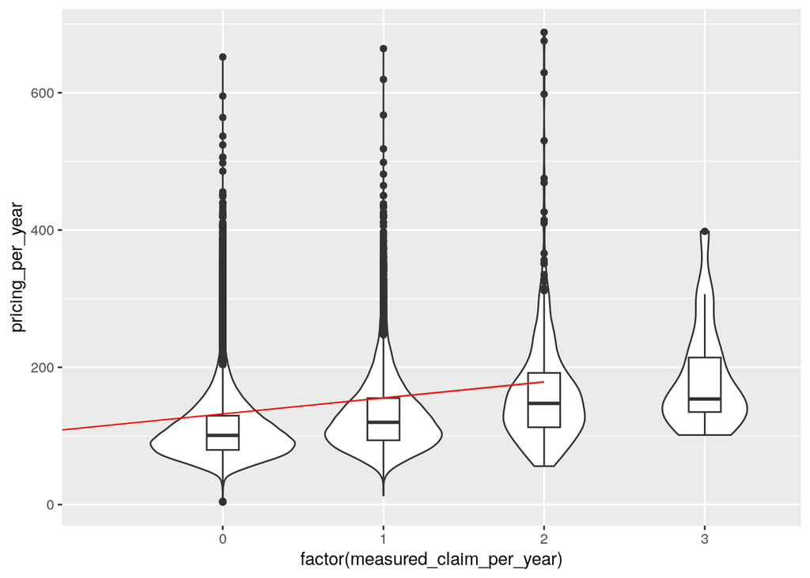

```r
fitted_subset <- predict(modelling_frequency,newdata=sub_data,type='response')
fitted_cost <- predict(modelling_damageprice,newdata=sub_data,type='response')
fiti = sub_data[, .(expected_claim_per_year = fitted_subset, measured_claim_per_year = nb_claims, expected_cost_per_claim = fitted_cost, measured_cost_perclaim = avg_claim_amount)]
fiti[,pricing_per_year := expected_cost_per_claim*expected_claim_per_year]

ggplot(fiti[measured_claim_per_year < 5], aes(y=pricing_per_year, x=factor(measured_claim_per_year)))+geom_violin()+geom_boxplot(width = 0.2)+geom_smooth(mapping = aes(x=measured_claim_per_year, y=pricing_per_year), method = "lm", col="red", lwd =0.4)
```

```r
# return on cost
sum(fiti$pricing_per_year)/sum(fiti$measured_claim_per_year*fiti$measured_cost_perclaim)
```

```
## [1] 1.204535
```

[1] is the amount charged money vs. claimed money (on the learned data)

Let’t fit the fullset of the data:

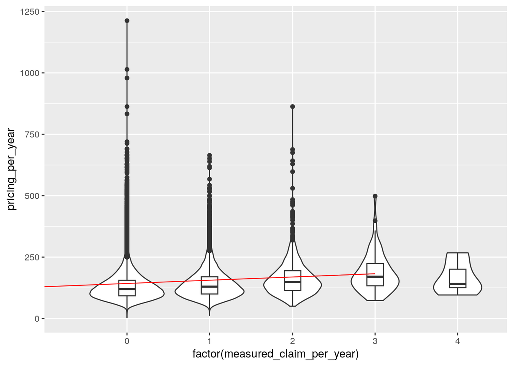

```r
full_fitted_subset <- predict(modelling_frequency,newdata=fulldata,type='response')
full_fitted_cost <- predict(modelling_damageprice,newdata=fulldata,type='response')
full_fiti = fulldata[, .(expected_claim_per_year = full_fitted_subset, measured_claim_per_year = round(nb_claims), expected_cost_per_claim = full_fitted_cost, measured_cost_perclaim = avg_claim_amount)]
full_fiti[,pricing_per_year := expected_cost_per_claim*expected_claim_per_year]

ggplot(full_fiti[measured_claim_per_year < 5], aes(y=pricing_per_year, x=factor(measured_claim_per_year)))+geom_violin()+geom_boxplot(width = 0.2)+geom_smooth(mapping = aes(x=measured_claim_per_year, y=pricing_per_year), method = "lm", col="red", lwd =0.4)
```

```r
# return on cost

sum(full_fiti$pricing_per_year)/sum(full_fiti$measured_claim_per_year*full_fiti$measured_cost_perclaim)
```

```
## [1] 1.47218
```

[1] is the amount charged money vs. claimed money for the whole data-set

Visualising Some factors

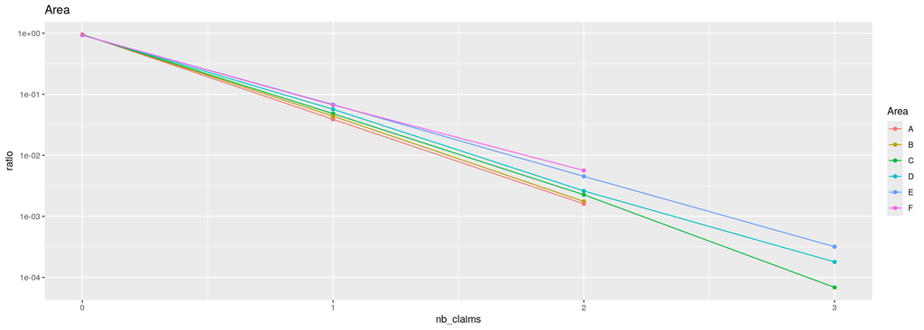

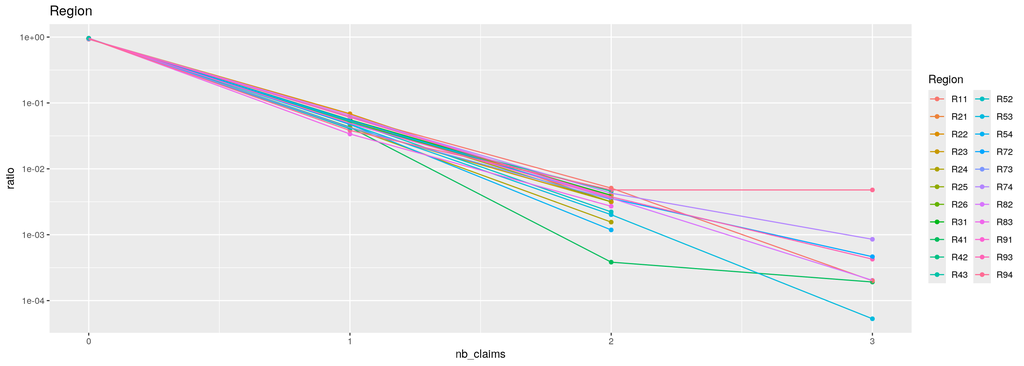

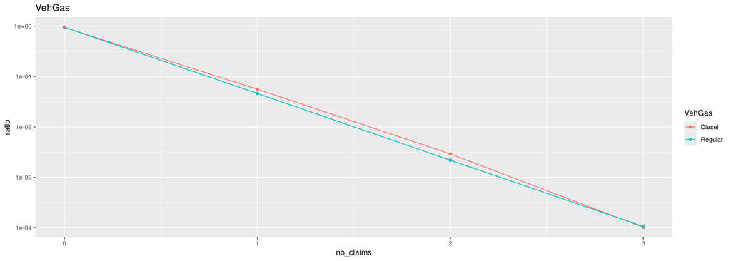

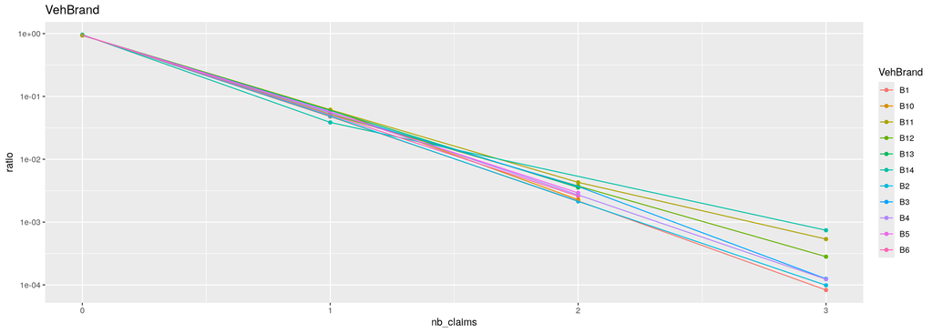

Some visalisation of the stronger effects on risk.

## Source

Full source for this report is available on https://github.com/moritzbuck/coburg_interview_challenge, and can be generated by running the `init.sh`-script in `src`. It should only require `conda` and `mamba`.